# Module 4: Data Visualization

## Common Aesthetics

Aesthetic mappings are unique to each geometric object. Some of the most common ones that show up in many geoms are provided below.

| aesthetic | purpose |
| --- | --- |
| `x` | Controls the x-variable in the plot. |
| `y` | Controls the y-variable in the plot. |
| `alpha` | Controls the transparency of the object. |
| `color`, `colour` | Controls the colors of the object. |
| `fill` | Controls the color of the interior of an object. |
| `group` | Controls how the data are grouped. |
| `linetype` | Controls the type of line used to draw the object. |
| `size` | Controls the size of the drawn object. |
| `shape` | Controls the shape of the object. |

## Bar Plots with `geom_bar`

- Use the `geom_bar()` to construct bar plots.
- No variable is mapped to the `fill` aesthetic in the `geom_bar()`.
  - Instead we map a fixed color to the `fill` aesthetic.
  - This changes the appearance of the plot.
  - But no additional features of the data are highlighted.

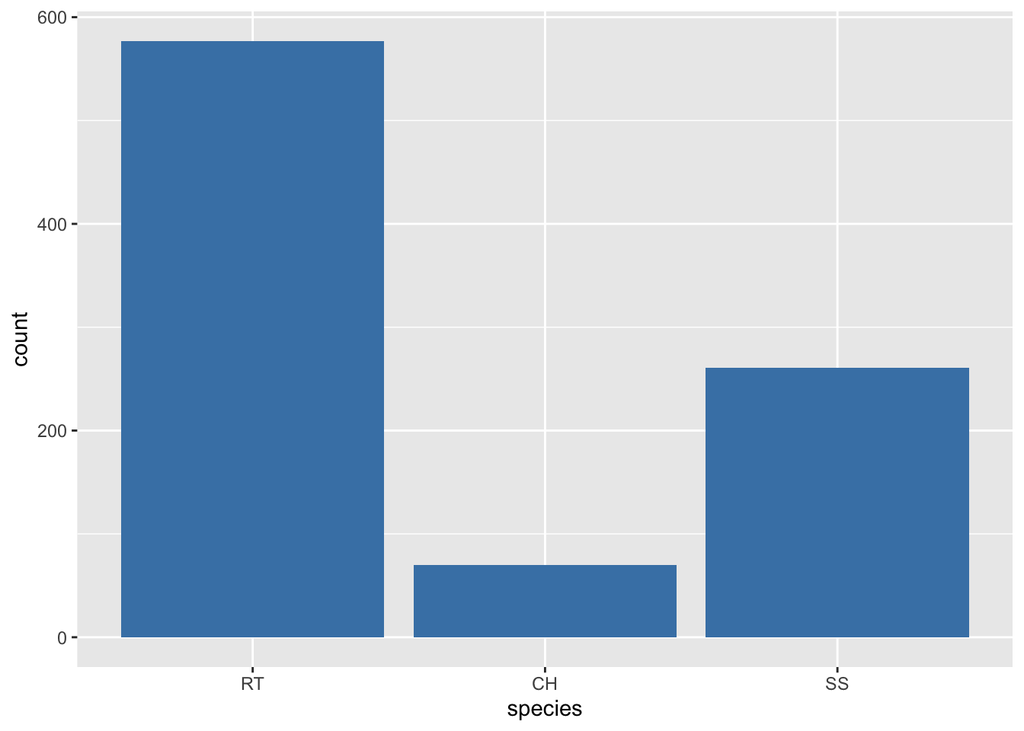

```r
ggplot(hawks, aes(x = species)) +  # plot factor variable species on x
  geom_bar(fill = "steelblue")  # use the same fill color for all bars
```

- If we map `species` to the `fill` aesthetic, then each bar is plotted in a different color.
  - That might look nice? Maybe not your style?
  - Since the same variable is mapped to both aesthetics, we gain no new information from the colors.

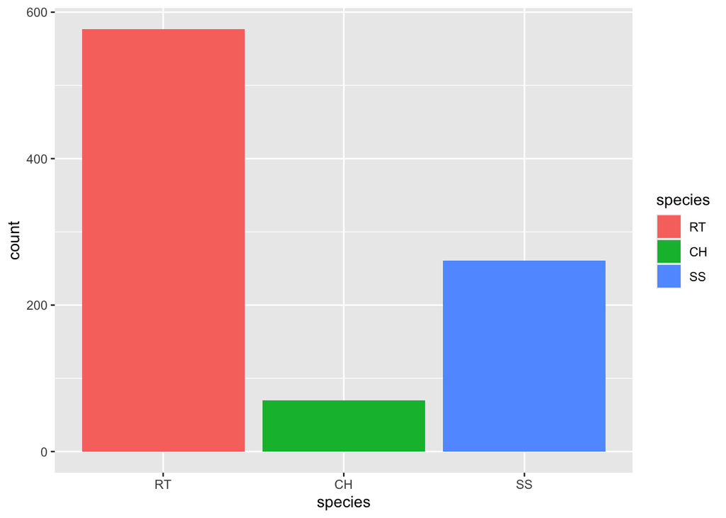

```r
ggplot(hawks, aes(x = species, fill = species)) +  # use diff color for diff species
  geom_bar()
```

- If we map a different factor variable, such as `age` to the `fill` aesthetic, then we do gain additional information.
- The result is a stacked frequency bar chart.

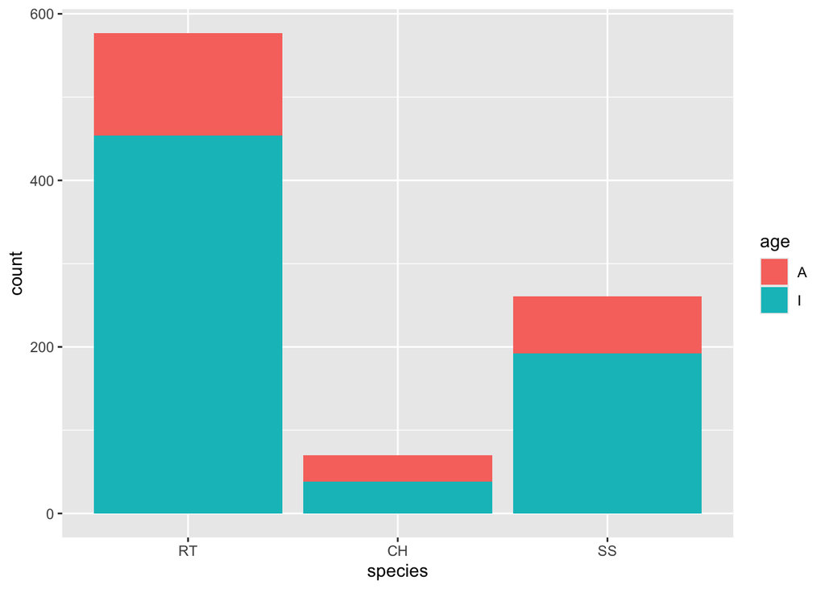

```r
# mapping a second variable to a second aesthetic conveys additional info
ggplot(hawks, aes(x = species, fill = age)) +
  geom_bar()
```

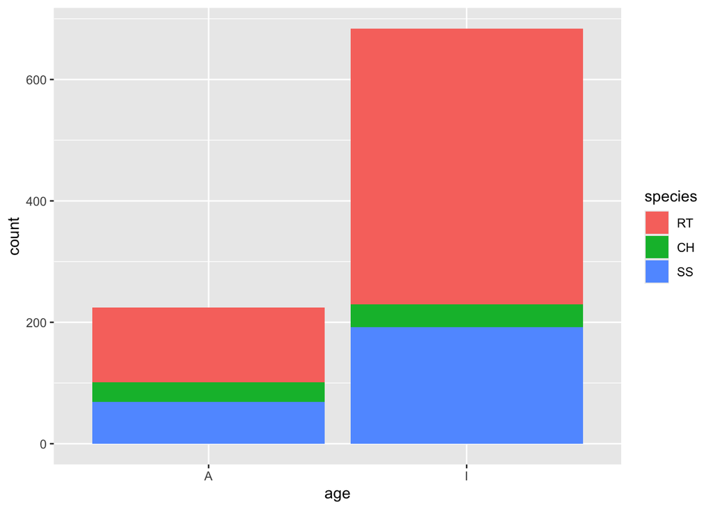

```r
# swapping variables and aesthetics results in different plot
ggplot(hawks, aes(x = age, fill = species)) +
  geom_bar()
```

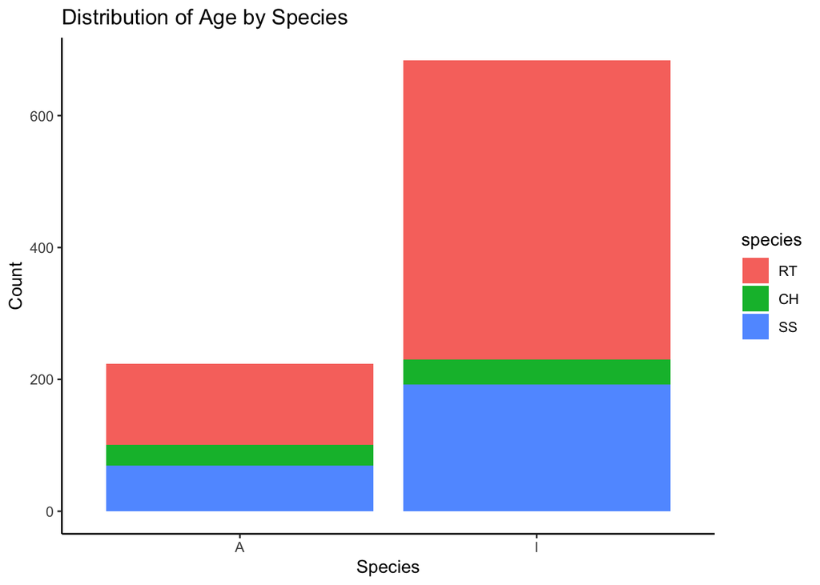

```r
# we add additional layers for improved layout
ggplot(hawks, aes(x = age, fill = species)) +
  geom_bar() +
  labs(
    title = "Distribution of Age by Species",  # add main title
    x = "Species", y = "Count"   # add label on each axis
  ) +
  theme_classic()
```

## Histograms with `geom_hist`

Use `geom_histogram()` to construct a histogram for a `numeric` variable that is mapped to the `x` aesthetic.

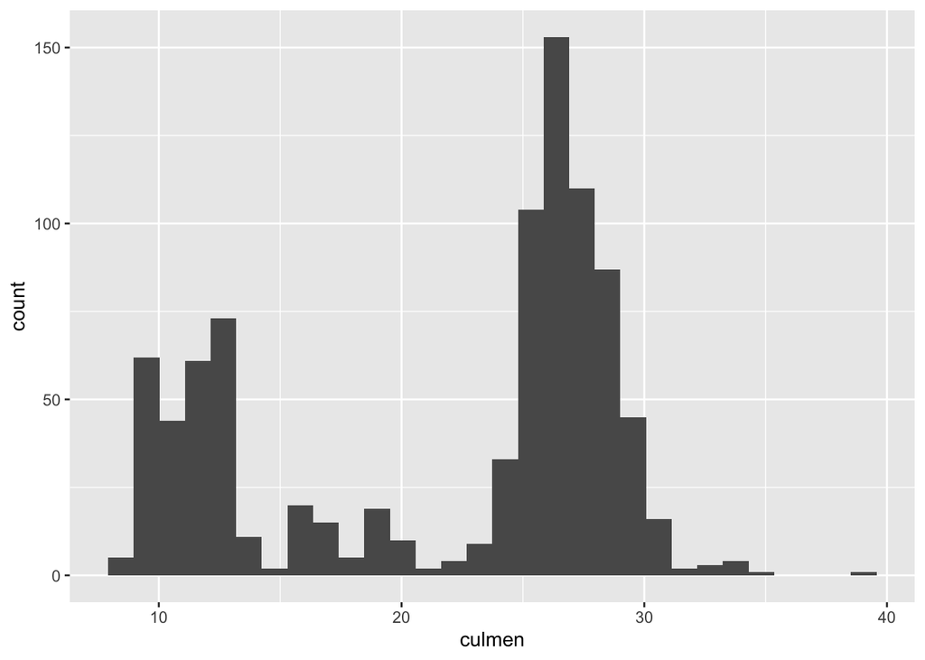

```r
ggplot(hawks, aes(x = culmen)) +
  geom_histogram()
```

- We can add additional options to customize `geom_histogram()`.
- Run `?geom_histogram` to access help documentation to view other available arguments.

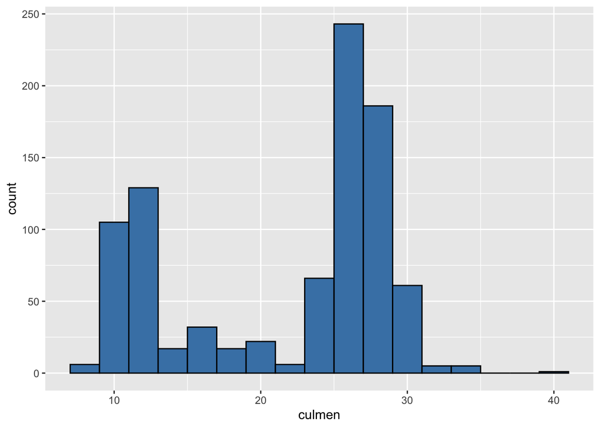

```r
ggplot(hawks, aes(x = culmen)) +
  geom_histogram(
    binwidth = 2,  # sets width of each bin to 2 mm
    fill = "steelblue",  # set fill color to steelblue
    color = "black"  # set outline color to black
    )
```

## Density Plots with `geom_density`

Use `geom_density()` to construct a density plot for a `numeric` variable that is mapped to the `x` aesthetic.

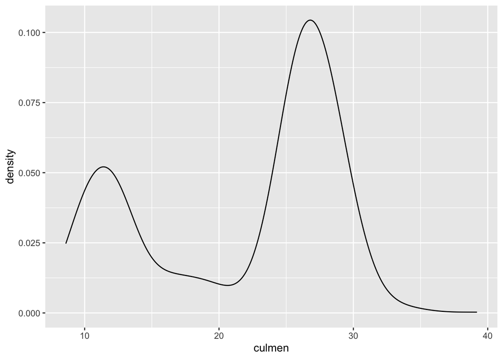

```r
ggplot(hawks, aes(x = culmen)) +
  geom_density()
```

- We can map other variables to other aesthetics to search for other lurking relations.

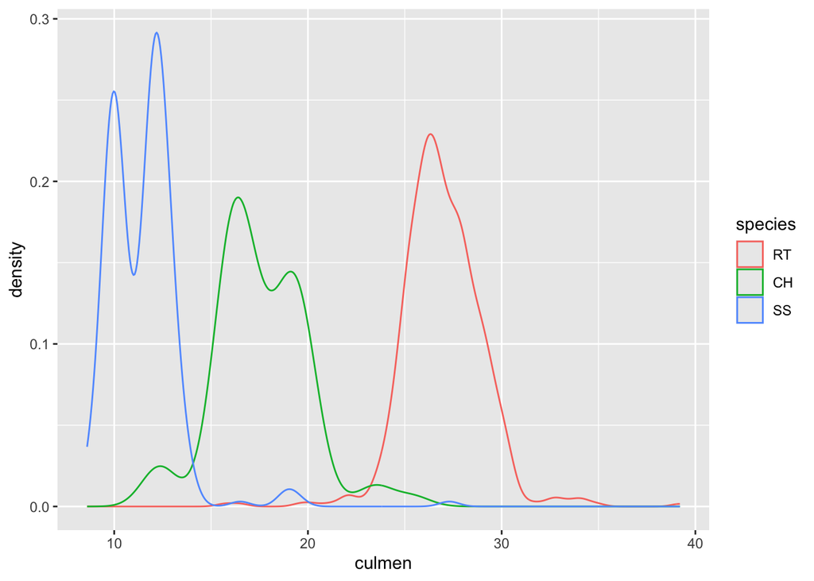

```r
ggplot(hawks, aes(x = culmen, color = species)) +
  geom_density()
```

- Since some people may not perceive colors as well as others, we can map a single variable to multiple aesthetics to communicate a relation using multiple modes such as `color` and `linetype`.

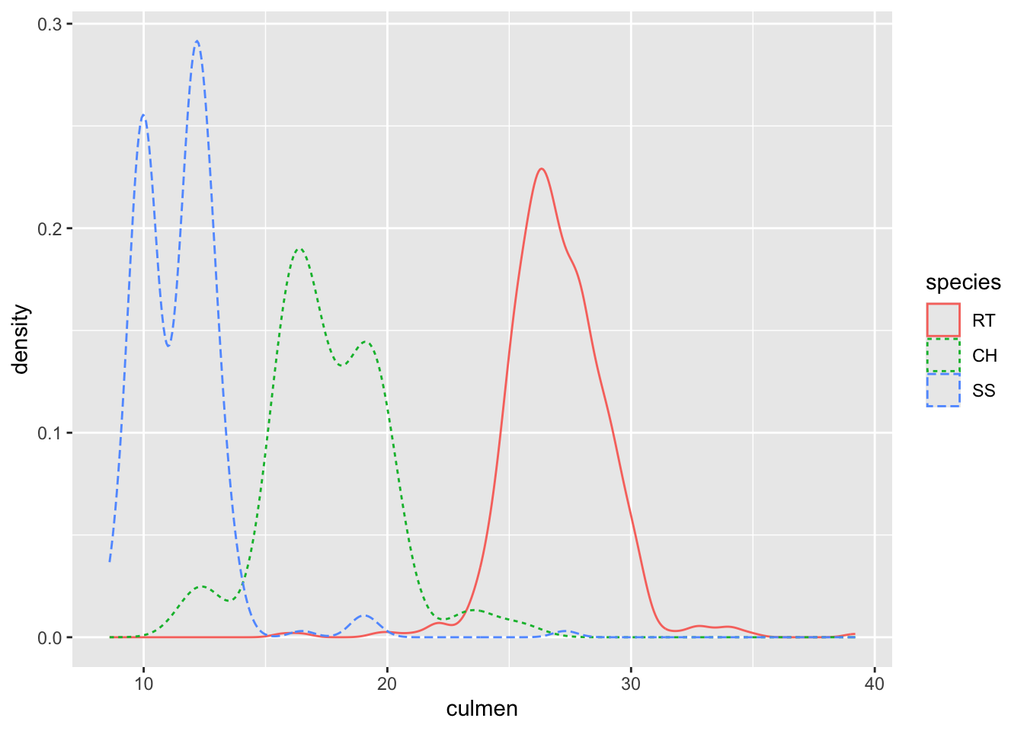

```r
ggplot(hawks, aes(x = culmen,
                  color = species,
                  linetype = species)) +
  geom_density()
```

- Some aesthetics may work better than others. Beauty is in the eye of the beholder. Express yourself through the language of `ggplot2` aesthetics.

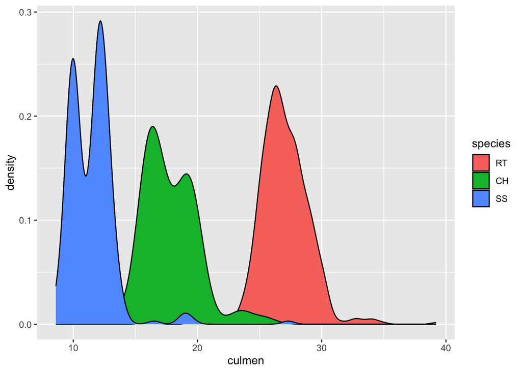

```r
ggplot(hawks, aes(x = culmen,
                  fill = species)) +
  geom_density()
```

### Adjusting Transparency with `alpha`

To address masking issues, we can control the transparency of the colors using the `alpha` aesthetic.

- `0` means completely transparent (not visible),
- `1` means completely opaque (cannot see anything behind it).

In the code cell below we set `alpha = 0.3`. Notice that we specify this in the `geom` layer, not in the aesthetic mapping, since we want to apply the same value to all density plots.

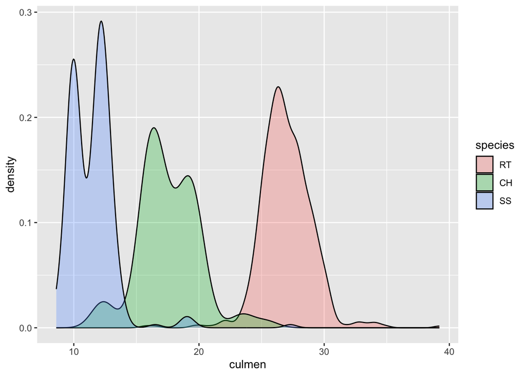

```r
ggplot(hawks, aes(x = culmen,
                  fill = species)) +
  geom_density(alpha = 0.3)  # add alpha aesthetic here
```

## Box Plots with `geom_boxplot`

Use `geom_boxplot()` to construct a box plot of a `numeric` variable mapped to the `x` aesthetic.

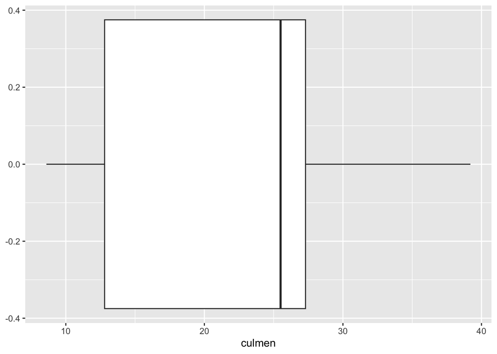

```r
ggplot(hawks, aes(x = culmen)) +
  geom_boxplot()
```

- We can always add additional layers for formatting and layout after working out how to convey important features and patterns in the data.

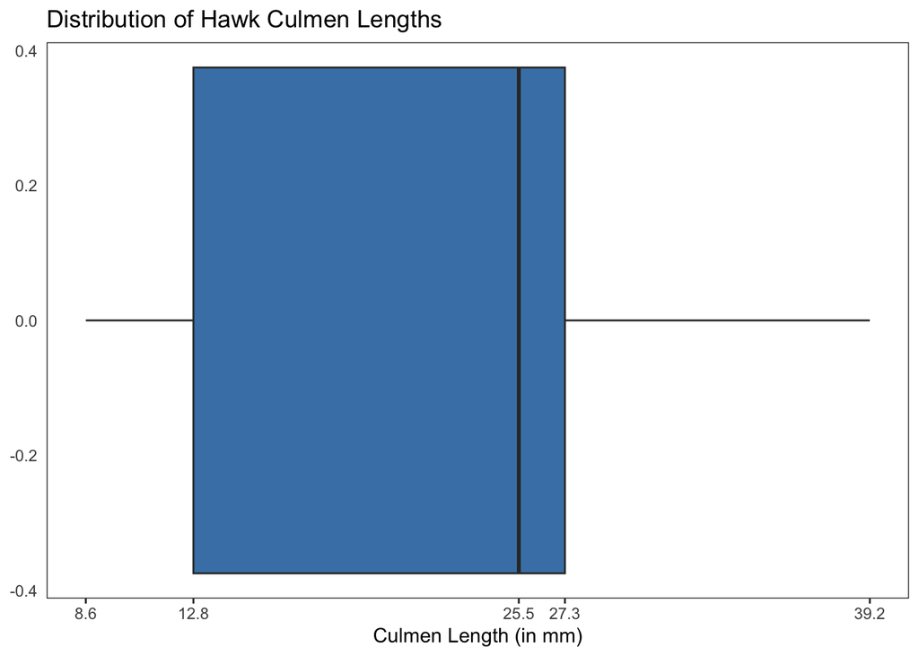

```r
ggplot(hawks, aes(x = culmen)) +
  geom_boxplot(fill = "steelblue") +  # set fill color to steelblue
  scale_x_continuous(breaks = fivenum(hawks$culmen)) +  # customize ticks on x-axis
  labs(
    title = "Distribution of Hawk Culmen Lengths",
    x = "Culmen Length (in mm)",
  ) +
  theme_bw() +  # use custom theme
  theme(
    axis.ticks.y=element_blank(),  # turn off y-axis ticks
    panel.grid.minor = element_blank(),  # remove minor gridlines
    panel.grid.major = element_blank())  # remove major gridlines
```

## Side-by-Side Boxplots with `geom_boxplot`

We can create side by side box plots by simply adding a categorical variable such as `species` to the opposite axis as the one the numeric variable is mapped to. In addition, a `fill` color to the box plots might be a more visually appealing graphic.

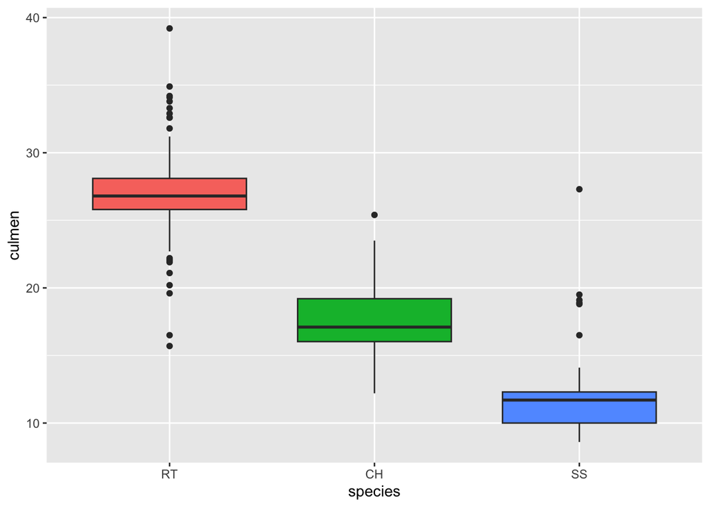

```r
ggplot(hawks, aes(x = species, y = culmen, fill = species)) +
  geom_boxplot() +
  theme(legend.position = "none")  # legend adds no new info in this case
```

## Violin Plots with `geom_violin`

A **violin plot** blends a box plot and a density plot. A violin plot unites a density with its mirror image and then displays the unified object like a box plot. Use `geom_violin()` to construct a violin plot for a `numeric` variable.

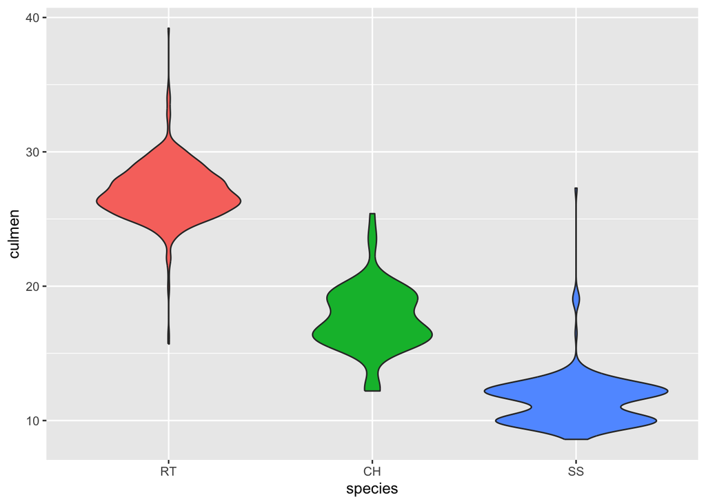

```r
ggplot(hawks, aes(x = species, y = culmen, fill = species)) +
  geom_violin() +
  theme(legend.position = "none")  # legend adds no new info in this case
```

## Adding Smoothers to Scatter Plots

A **smoother** in `ggplot2` is a model that that attempts to estimate the average relationship between a response variable (typically the `y` variable) and one or more predictor variables (typically the `x` and possibly other variables).

- A smoothing layer can be added to a plot using `geom_smooth`.
- Adding a smoother to a plot can make relationships between variables even clearer.
- A pointwise confidence interval is shaded in gray by default to include an assessment of uncertainty.
  - We can turn off with confidence interval shading with the option `geom_smooth(se = FALSE)`.

There are many different models we can choose for the smoothing `method`. `ggplot2` takes the methods:

- `lm` (linear model),
- `glm` (generalized linear model),
- `gam` (generalized additive model),
- `loess` (local fitting),
- or a function (e.g., `MASS::rlm` for a robust linear model).

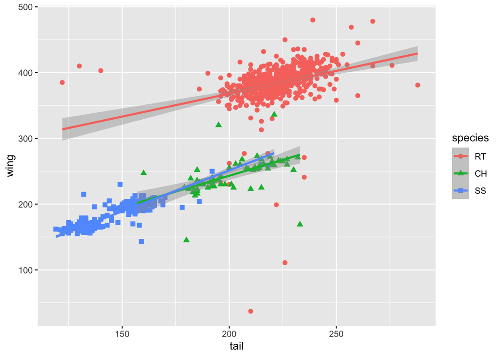

```r
ggplot(hawks, aes(x = tail, y = wing, color = species, shape = species)) +
  geom_point(size = 2) +
  geom_smooth(method = "lm")
```

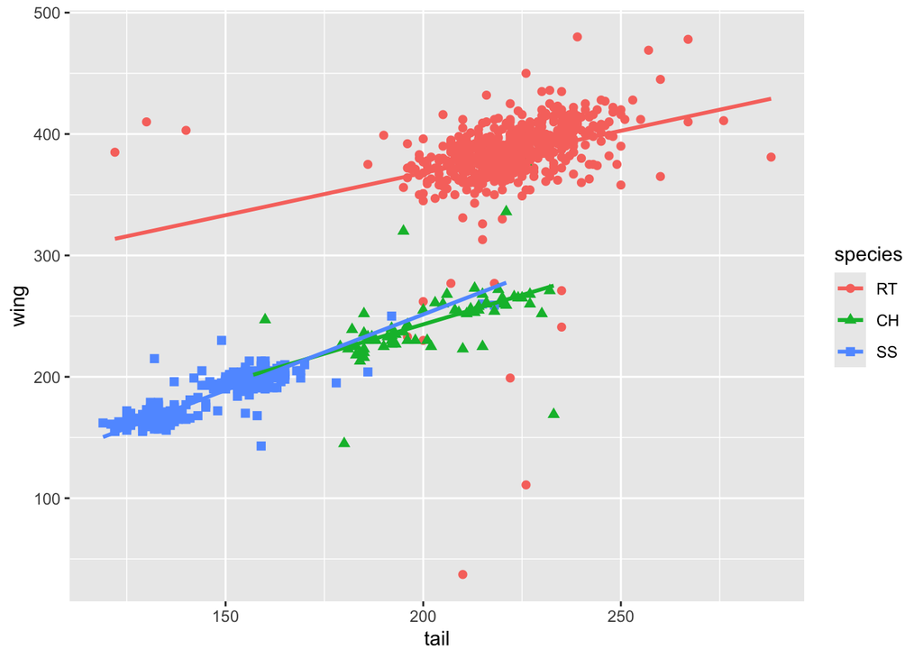

```r
# turn off conf int band with se = FALSE argument
ggplot(hawks, aes(x = tail, y = wing, color = species, shape = species)) +
  geom_point(size = 2) +
  geom_smooth(method = "lm", se = FALSE)
```

## Adjusting Color Palette for Colorblind-Friendly Plots

We can improve the color palette to be more colorblind-friendly with the [`scale_color_colorblind()`](https://jrnold.github.io/ggthemes/reference/colorblind.html) function from the `ggthemes` package.

**Warning**

If you have not already install the `ggthemes` package, you will need to first run the command `install.packages("ggthemes")` from the console below.

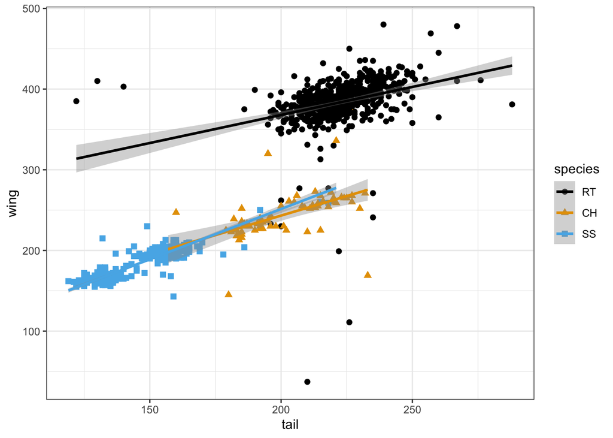

```r
#library(ggthemes)  # loaded in first code cell
ggplot(hawks, aes(x = tail, y = wing, color = species, shape = species)) +
  geom_point(size = 2) +
  geom_smooth(method = "lm") +
  scale_color_colorblind() + # adjust color palette
  theme_bw()
```

## Local vs. Global Aesthetic Mappings

In `ggplot2`, there are two ways to map a variable to an aesthetic:

- A **global aesthetic mapping** applies across all geoms and is specified in the `ggplot` function
- A **local aesthetic mapping** is specified in a specific geom function and only applies to that particular geom.

In the plot above, we applied a global aesthetic mapping to the `species` variable using the `color` aesthetic to obtain three separate linear models for each of the three different species, resulting in a more complete picture.

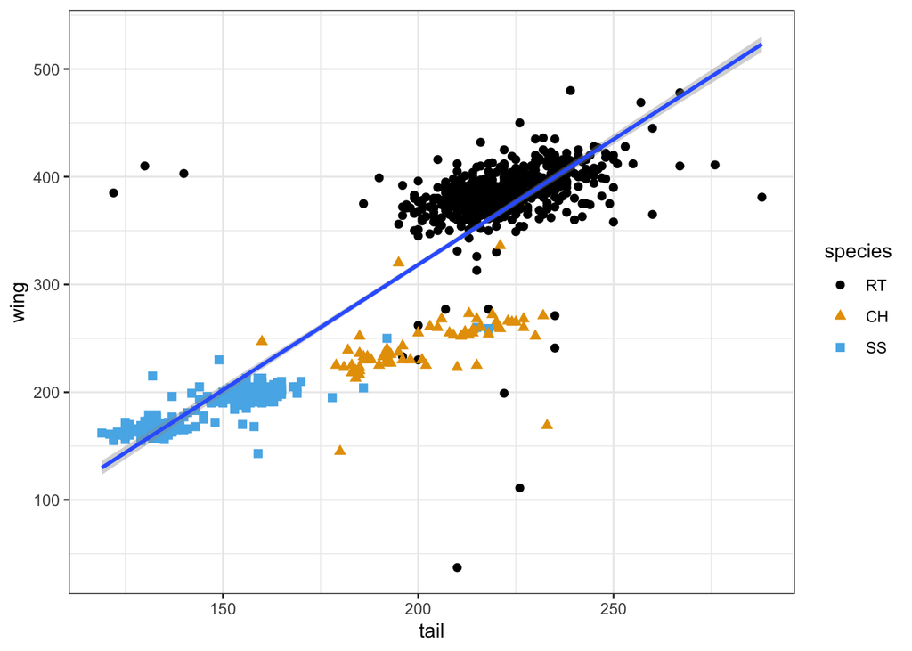

```r
ggplot(hawks, aes(x = tail, y = wing)) +
  geom_point(aes(color = species, shape = species), size = 2) +
  geom_smooth(method = "lm") +
  scale_color_colorblind() + # adjust color palette
  theme_bw()
```

## Faceting

**Faceting** a `ggplot` creates separate plotting panels for each level of one or more categorical variables. Faceting creates arrays of plots by subsetting and displaying the same graph for each subset of the data. Technically, faceting can be performed for discrete `numeric` variables with a relatively small number of unique values, but for practical reasons, faceting is most appropriate for `factor` variables.

There are two functions for creating faceted graphics in `ggplot2`:

- `facet_wrap` facets the plots based on a single `factor` variable. The panels are wrapped around the plotting window.
  - Wrapped is typically the more useful type of faceting.
- `facet_grid` forms a matrix of panels based on row and column faceting variables.

### Wrapped Faceting

In the plot below, we facet scatter plots of `wing` versus `tail` by `species`, and in addition we change the color of points to indicate the age group.

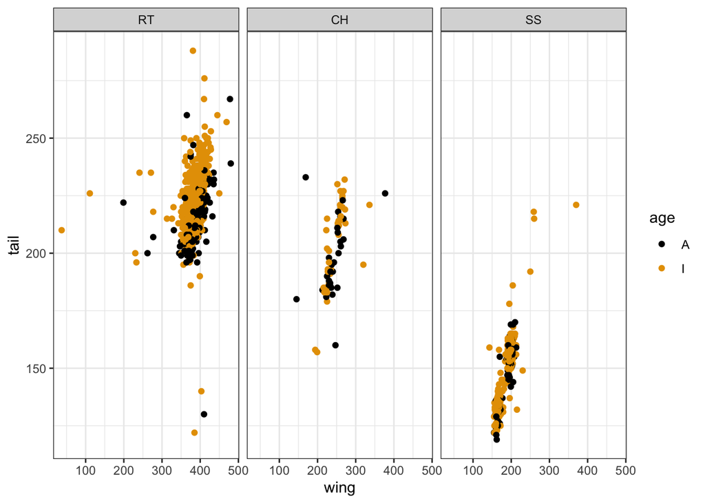

```r
ggplot(hawks, aes(x = wing, y = tail, color = age)) +
  geom_point() +
  facet_wrap(~species) +
  scale_color_colorblind() + # adjust color palette
  theme_bw()
```

### Grid Faceting

We now explore the `facet_grid` function to facet by the `factor` variables `species` and `age`.

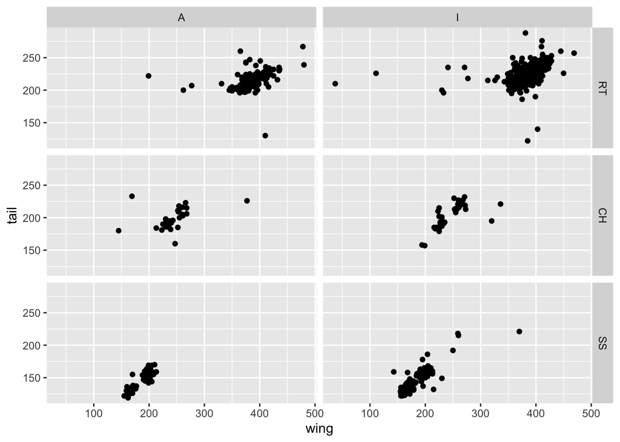

```r
ggplot(hawks, aes(x = wing, y = tail)) +
  geom_point() +
  facet_grid(species ~ age)
```

# Practice

The `dplyr` package contains a data set called `storms` that contains 19,537 observations and 13 variables from storms that have occurred in the North Atlantic from 1975-2022. Run `?storms` from the console below to open up documentation to learn more about the data stored in `storms`. In particular, make sure you understand what the variables in the data set are measuring and if there are any data cleaning issues.

```r
summary(storms)
```

```
     name                year          month             day
 Length:19537       Min.   :1975   Min.   : 1.000   Min.   : 1.00
 Class :character   1st Qu.:1994   1st Qu.: 8.000   1st Qu.: 8.00
 Mode  :character   Median :2004   Median : 9.000   Median :16.00
                    Mean   :2003   Mean   : 8.706   Mean   :15.73
                    3rd Qu.:2013   3rd Qu.: 9.000   3rd Qu.:24.00
                    Max.   :2022   Max.   :12.000   Max.   :31.00

      hour             lat             long                         status
 Min.   : 0.000   Min.   : 7.00   Min.   :-136.90   tropical storm     :6830
 1st Qu.: 5.000   1st Qu.:18.30   1st Qu.: -78.80   hurricane          :4803
 Median :12.000   Median :26.60   Median : -62.30   tropical depression:3569
 Mean   : 9.101   Mean   :27.01   Mean   : -61.56   extratropical      :2151
 3rd Qu.:18.000   3rd Qu.:33.80   3rd Qu.: -45.50   other low          :1453
 Max.   :23.000   Max.   :70.70   Max.   :  13.50   subtropical storm  : 298
                                                    (Other)            : 433
    category          wind           pressure      tropicalstorm_force_diameter
 Min.   :1.000   Min.   : 10.00   Min.   : 882.0   Min.   :   0.0
 1st Qu.:1.000   1st Qu.: 30.00   1st Qu.: 986.0   1st Qu.:   0.0
 Median :1.000   Median : 45.00   Median :1000.0   Median : 110.0
 Mean   :1.896   Mean   : 50.05   Mean   : 993.5   Mean   : 147.9
 3rd Qu.:3.000   3rd Qu.: 65.00   3rd Qu.:1007.0   3rd Qu.: 220.0
 Max.   :5.000   Max.   :165.00   Max.   :1024.0   Max.   :1440.0
 NA's   :14734                                     NA's   :9512
 hurricane_force_diameter
 Min.   :  0.00
 1st Qu.:  0.00
 Median :  0.00
 Mean   : 14.92
 3rd Qu.:  0.00
 Max.   :300.00
 NA's   :9512
```

## Question 11

Clean up any issues you see with the data.

### Solution to Question 11

## Question 12

Create one univariate plot for a `numeric` variable in `storms` using any method you prefer.

### Solution to Question 12

## Question 13

Create one univariate plot for a categorical variable in `storms` using any method you prefer.

### Solution to Question 13

## Question 14

Create a scatter plot to see whether there is a relation between two `numeric` variables in `storms`.

### Solution to Question 14

## Question 15

Create a side-by-side box plots or violin plots to compare the distribution of a `numeric` variable for different levels of a categorical variable in `storms`.

### Solution to Question 15

# Interactive Plots with `plotly`

Interactive graphics are visual displays that dynamically provide information to users based on the user interacting with the graphic. Some of the best packages for creating interactive graphics in R are:

- [`plotly`](https://plotly.com/): provides functions to make `ggplot2` graphics interactive and a custom interface to the JavaScript library `plotly.js` inspired by the grammar of graphics. This is perhaps the best known interactive visualization library.
- [`ggiraph`](https://davidgohel.github.io/ggiraph/): creates interactive `ggplot2` graphics using [`htmlwidgets`](https://cran.r-project.org/web/packages/rgl/index.html).
- [`rgl`](https://cran.r-project.org/web/packages/rgl/index.html): provides functions for 3D interactive graphics using OpenGL or to various standard 3D file formats
- [`shiny`](https://shiny.posit.co/): a package for creating interactive web apps.

If we are already familiar with `ggplot2`, then `plotly` is super convenient. The easiest way to create interactive graphics with `ggplot2` and `plotly` is to:

1. Create a plot using `ggplot2`.
2. Use the `ggplotly()` function from the `plotly` package to make the graphic interactive.

That’s it. We now can make just about any `ggplot2` plot interactive.

**Warning**

If you have not already install the `plotly` package, you will need to first run the command `install.packages("plotly")` from the console below.

## Interactive Bar Plots

1. Use `ggplot2` to create a basic bar plot of hawk `species`.
2. Use the `ggplotly()` function to convert the static `ggplot` to an interactive plot

**Warning**

If you have not already install the `plotly` package, you will need to first run the command `install.packages("plotly")` from the console below. The `plotly` package is loaded in the first code cell of this document. If you have not run that code cell, be sure to run the command `library(plotly)` to load the package before running the code cell below.

```r
# first create and store ggplot bar plot
#library(plotly)
ggbar <- ggplot(hawks, aes(x = species)) +
  geom_bar()

# then input into ggplotly to make it interactive
ggplotly(ggbar)
```

[interactive chart not shown]

## Interactive Histograms

First create a histogram with `geom_histogram()`. Then input into `ggplotly()`. Scroll around the plot and use the tool bar on top to interact with the plot.

```r
gghist <- ggplot(hawks, aes(x = culmen)) +
  geom_histogram(bins = 20)

ggplotly(gghist)
```

[interactive chart not shown]

## Interactive Density Plots

First create a density plot with `geom_density()`. Then input into `ggplotly()`. Scroll around the plot and use the tool bar on top to interact with the plot.

```r
ggdens <- ggplot(hawks, aes(x = culmen, fill = species)) +
  geom_density(alpha = 0.3)

ggplotly(ggdens)
```

[interactive chart not shown]

## Interactive Box Plots

First create a box plot with `geom_boxplot()`. Then input into `ggplotly()`. Scroll around the plot and use the tool bar on top to interact with the plot.

```r
ggbox <- ggplot(hawks, aes(x = species, y = culmen)) +
  geom_boxplot()
ggplotly(ggbox)
```

[interactive chart not shown]

## Interactive Scatter Plots

First create a scatter plot with `geom_point()`. Then input into `ggplotly()`. Scroll around the plot and use the tool bar on top to interact with the plot.

```r
ggscatter <-
  ggplot(hawks,
         aes(x = wing,
             y = tail,
             color = species,
             shape = species)) +
  geom_point()
ggplotly(ggscatter)
```

[interactive chart not shown]

Notice that `species` is indicated twice when we hover over a point. We can correct this behavior by using the `tooltip` argument to specify the attributes (`x`, `y`, `color`, etc.) we want to display when our mouse hovers over a point.

```r
# restrict attributes displayed from hover
ggplotly(ggscatter,
         tooltip = c("shape", "x", "y"))
```

[interactive chart not shown]

## Adding Smooths to an Interactive Scatter Plot Using `ggplot2` and `ggplotly()`

In the code below, we:

1. Use `ggplot2` to create a scatter plot of `wing` versus `tail` that uses different colors and shapes to distinguish the different `species`.
2. Add a second layer to the plot the provides an `"lm"` smooth for the points of each `species`. We assign this plot the name `ggsmooth`.
3. Use `plotly::ggplotly` to make the graphic interactive.

```r
ggsmooth <- ggplot(hawks, aes(x = wing,
                              y = tail,
                              color = species,
                              shape = species)) +
  geom_point() +
  geom_smooth(method = "lm")

ggplotly(ggsmooth)
```

[interactive chart not shown]

# Appendix: Color Palettes Available with `base` R

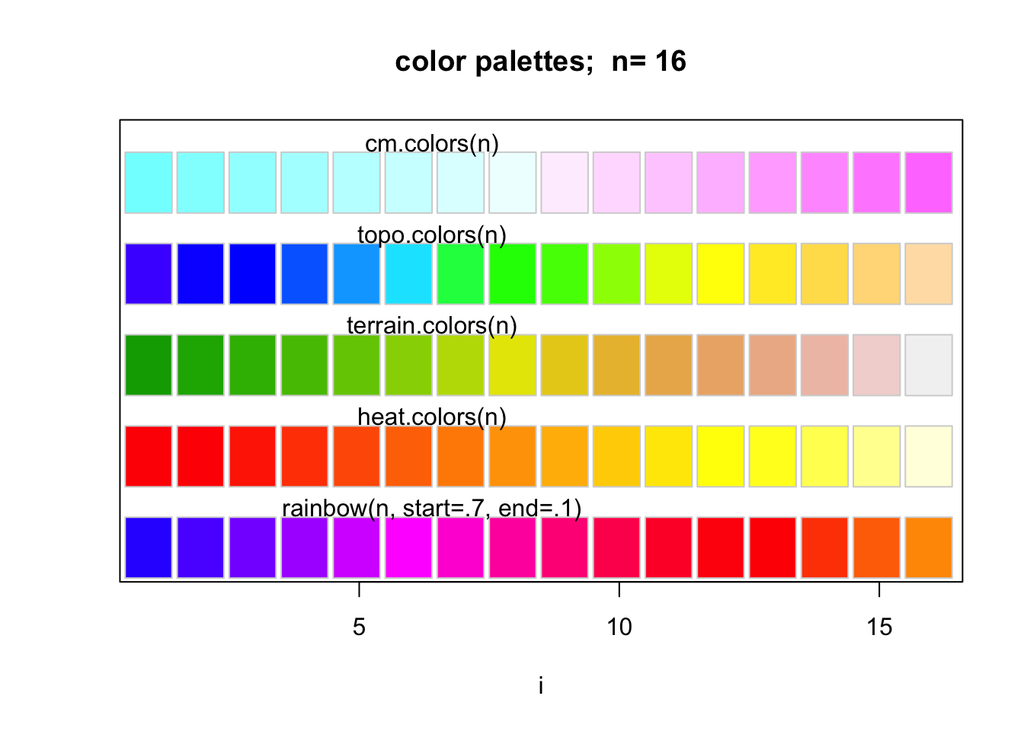

# Appendix: Color Swatches for HCL Palettes

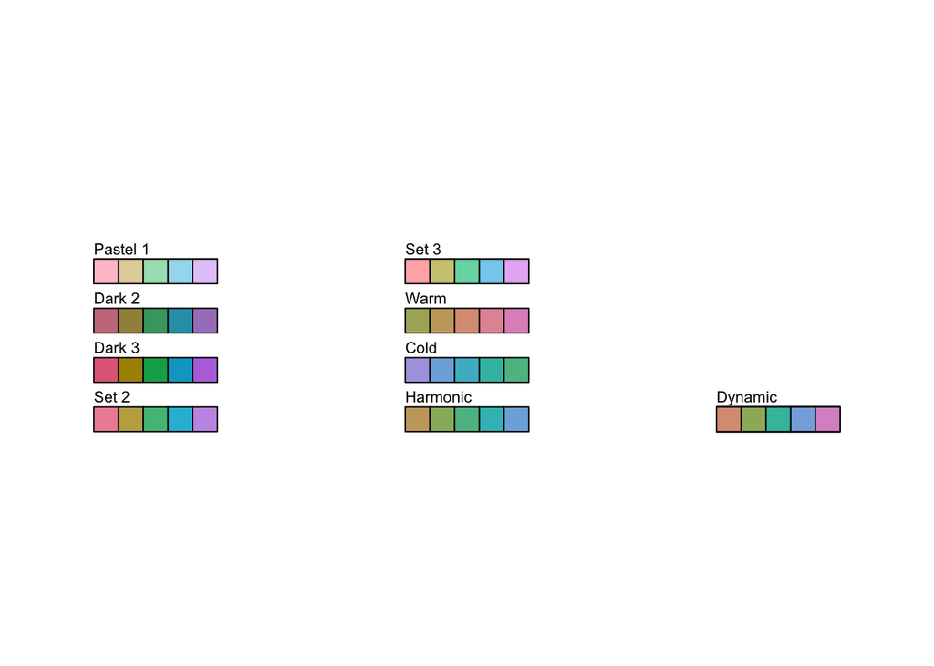

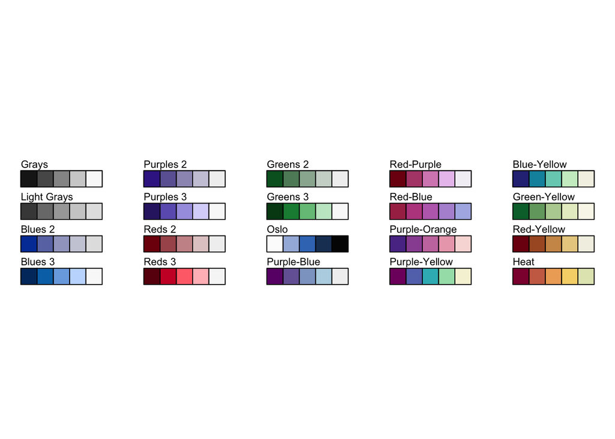

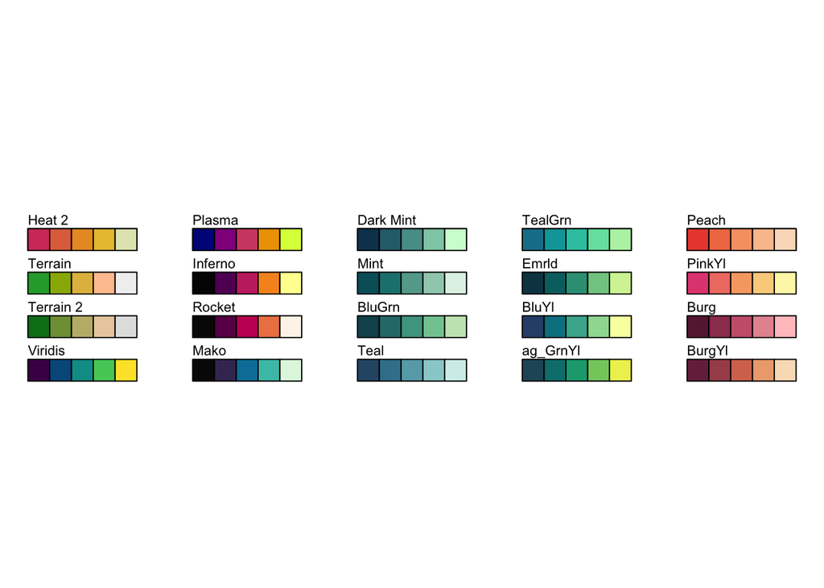

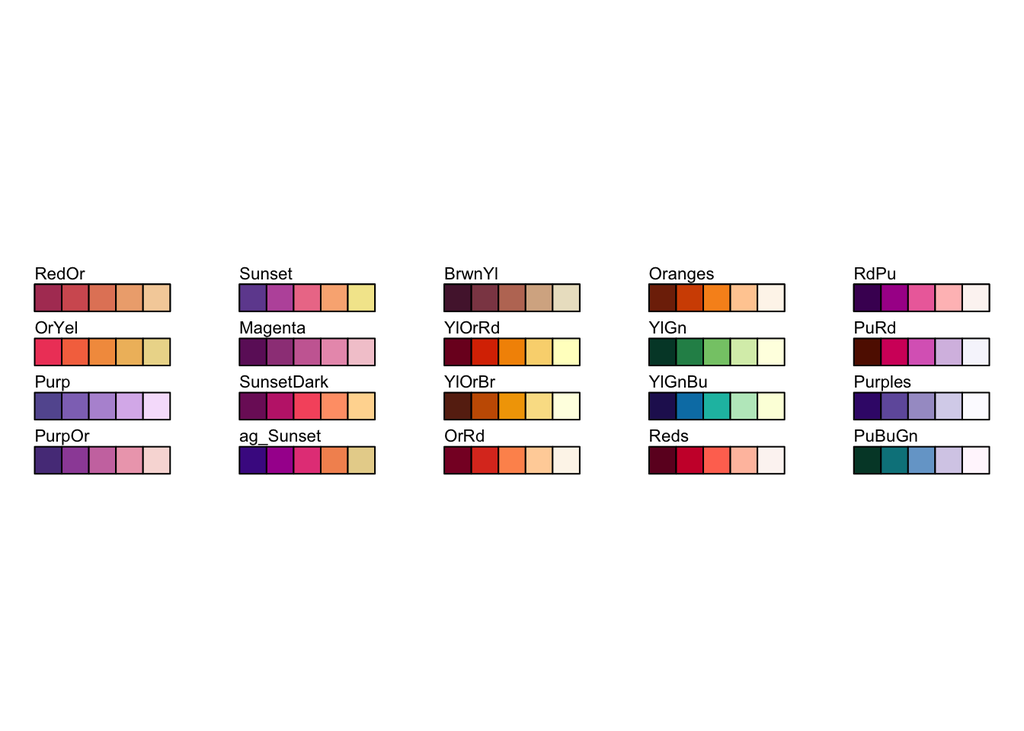

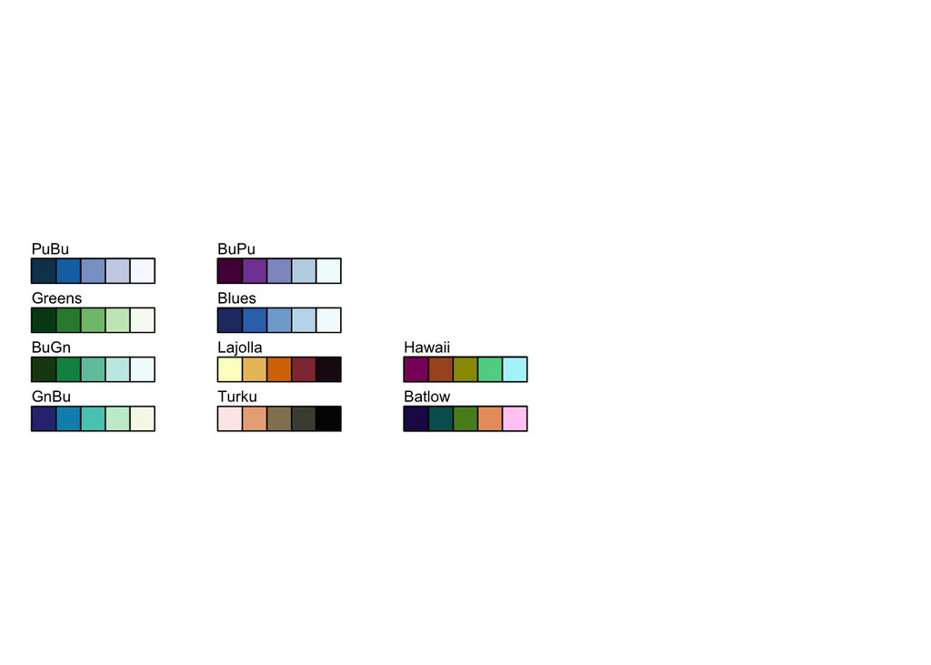

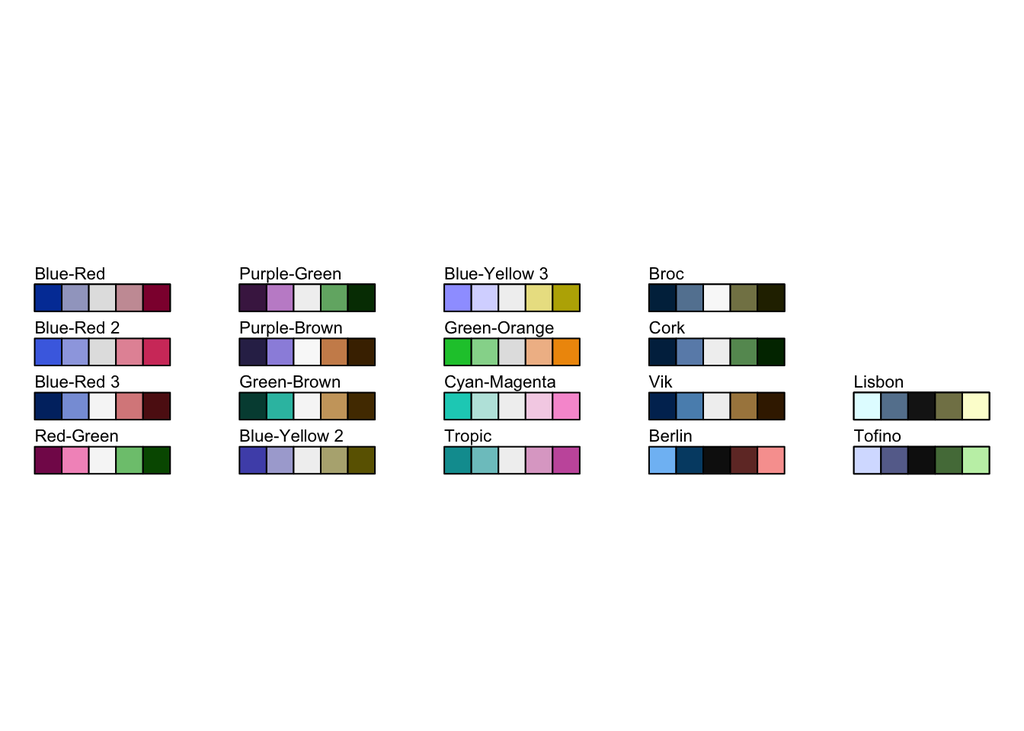

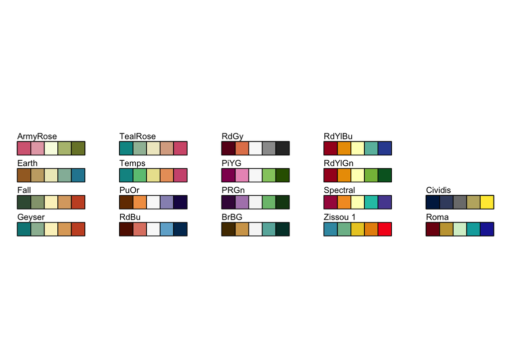